# The Full House Model for cross-era comparisons of baseball players (part II: A deeper look at results and fun digressions)

Daniel J. Eck and Shen Yan and Adrian Burgos Jr. and Christopher Kinson and Brandon Niedert

In this part of the series, we explore interesting era-adjusted careers and HOF discussions. We will discuss Joe Posnanski’s recent rankings list, how our method fits within a spirited conversation between Bill James and Tom Tango, and ESPN’s top 100 list. We will wrap up with a light discussion on ZiPS Projections.

## The New Colossuses of Clout: Barry Bonds and Willie Mays

In the first part of this series, we presented new rankings according to era-adjusted versions of many metrics. From this we see that Barry Bonds and Willie Mays sit atop the eWAR ranking lists suggesting that their contributions towards winning games was more than any other player in history including the old Colossus of Clout: Babe Ruth. Technically, our lists in part I were divided by batting and pitching stats. Such a distinction does not matter here - adding in Ruth’s pitching stats does not alter our conclusions. In fact, Roger Clemens and Hank Aaron both join Barry Bonds and Willie Mays in the club of players who have been more productive than Babe Ruth.

Here are the top players from the combined hitting and pitching eWAR rankings:

| rank | name | ebWAR | rank | name | efWAR |
| --- | --- | --- | --- | --- | --- |
| 1 | Barry Bonds | 154.80 | 1 | Barry Bonds | 152.69 |
| 2 | Willie Mays | 145.47 | 2 | Willie Mays | 138.04 |
| 3 | Roger Clemens | 141.78 | 3 | Roger Clemens | 131.18 |
| 4 | Henry Aaron | 129.65 | 4 | Henry Aaron | 125.00 |
| 5 | Babe Ruth | 122.81 | 5 | Babe Ruth | 119.16 |
| 6 | Alex Rodriguez | 121.01 | 6 | Alex Rodriguez | 116.66 |
| 7 | Greg Maddux | 111.58 | 7 | Greg Maddux | 115.29 |
| 8 | Albert Pujols | 111.03 | 8 | Mike Schmidt | 107.80 |
| 9 | Mike Schmidt | 110.43 | 9 | Rickey Henderson | 106.86 |
| 10 | Rickey Henderson | 107.79 | 10 | Nolan Ryan | 105.23 |

Barry Bonds stands alone and towers above the rest. Even after projecting Bonds’ stats into the less prolific contexts of the late 70s, 80s, and early 90s reveals his utter dominance:

| name | age | year | PA | AB | H | HR | BB | BA | OBP | ABpHR | ebWAR | efWAR | ebWARp100PA | efWARp100PA |
| --- | --- | --- | --- | --- | --- | --- | --- | --- | --- | --- | --- | --- | --- | --- |
| Barry Bonds | 21 | 1986 | 521 | 396 | 87 | 16 | 62 | 0.220 | 0.327 | 24.75 | 4.26 | 4.01 | 0.82 | 0.77 |
| Barry Bonds | 22 | 1987 | 606 | 514 | 125 | 17 | 56 | 0.243 | 0.319 | 30.24 | 5.46 | 5.13 | 0.90 | 0.85 |
| Barry Bonds | 23 | 1988 | 621 | 511 | 144 | 24 | 72 | 0.282 | 0.371 | 21.29 | 6.19 | 5.50 | 1.00 | 0.89 |
| Barry Bonds | 24 | 1989 | 684 | 569 | 153 | 22 | 84 | 0.269 | 0.362 | 25.86 | 7.53 | 6.70 | 1.10 | 0.98 |
| Barry Bonds | 25 | 1990 | 429 | 429 | 132 | 19 | 74 | 0.308 | 0.408 | 22.58 | 7.47 | 7.04 | 1.74 | 1.64 |
| Barry Bonds | 26 | 1991 | 647 | 470 | 144 | 29 | 99 | 0.306 | 0.422 | 16.21 | 8.47 | 8.27 | 1.31 | 1.28 |
| Barry Bonds | 27 | 1992 | 613 | 446 | 140 | 33 | 110 | 0.314 | 0.449 | 13.52 | 8.33 | 9.46 | 1.36 | 1.54 |
| Barry Bonds | 28 | 1993 | 658 | 504 | 167 | 40 | 112 | 0.331 | 0.450 | 12.60 | 9.37 | 9.62 | 1.42 | 1.46 |
| Barry Bonds | 29 | 1994 | 651 | 518 | 159 | 38 | 111 | 0.307 | 0.433 | 13.63 | 8.64 | 8.57 | 1.33 | 1.32 |
| Barry Bonds | 30 | 1995 | 691 | 553 | 169 | 38 | 124 | 0.306 | 0.434 | 14.55 | 7.75 | 7.93 | 1.12 | 1.15 |
| Barry Bonds | 31 | 1996 | 654 | 485 | 147 | 35 | 141 | 0.303 | 0.457 | 13.86 | 8.48 | 8.18 | 1.30 | 1.25 |
| Barry Bonds | 32 | 1997 | 680 | 504 | 148 | 37 | 130 | 0.294 | 0.442 | 13.62 | 7.61 | 7.40 | 1.12 | 1.09 |
| Barry Bonds | 33 | 1998 | 678 | 511 | 154 | 32 | 132 | 0.301 | 0.447 | 15.97 | 8.78 | 8.36 | 1.29 | 1.23 |
| Barry Bonds | 34 | 1999 | 428 | 320 | 93 | 29 | 97 | 0.291 | 0.456 | 11.03 | 5.95 | 5.60 | 1.39 | 1.31 |
| Barry Bonds | 35 | 2000 | 572 | 425 | 133 | 41 | 112 | 0.313 | 0.453 | 10.37 | 8.14 | 7.60 | 1.42 | 1.33 |
| Barry Bonds | 36 | 2001 | 639 | 465 | 156 | 45 | 128 | 0.335 | 0.485 | 10.33 | 9.05 | 9.35 | 1.42 | 1.46 |
| Barry Bonds | 37 | 2002 | 603 | 423 | 159 | 47 | 121 | 0.376 | 0.521 | 9.00 | 8.68 | 8.96 | 1.44 | 1.49 |
| Barry Bonds | 38 | 2003 | 412 | 379 | 136 | 43 | 96 | 0.359 | 0.497 | 8.81 | 7.57 | 7.55 | 1.84 | 1.83 |
| Barry Bonds | 39 | 2004 | 540 | 420 | 150 | 52 | 108 | 0.357 | 0.494 | 8.08 | 7.55 | 7.93 | 1.40 | 1.47 |
| Barry Bonds | 40 | 2005 | 93 | 28 | 9 | 9 | 52 | 0.321 | 0.753 | 3.11 | 3.04 | 3.22 | 3.27 | 3.46 |
| Barry Bonds | 41 | 2006 | 469 | 306 | 86 | 33 | 98 | 0.281 | 0.467 | 9.27 | 3.80 | 3.54 | 0.81 | 0.75 |
| Barry Bonds | 42 | 2007 | 473 | 308 | 78 | 35 | 104 | 0.253 | 0.444 | 8.80 | 2.68 | 2.77 | 0.57 | 0.59 |

Even through 1998, Bonds’ stats are dominant:

| name | PA | AB | H | HR | BB | BA | OBP | ABpHR | ebWAR | efWAR | ebWARp100PA | efWARp100PA |
| --- | --- | --- | --- | --- | --- | --- | --- | --- | --- | --- | --- | --- |
| Barry Bonds | 8133 | 6410 | 1869 | 380 | 1307 | 0.292 | 0.412 | 16.87 | 98.34 | 96.17 | 1.21 | 1.18 |

After Bonds comes Willie Mays who also towers well above the rest of the field. His stats were compiled in an era that was often tilted to favor pitching, in a NL that was far quicker to integrate than the AL, and in a stadium in which fly balls went to die. Through this Mays was dominant and it can be argued that his prime was better than any, including Bonds:

| name | age | year | PA | AB | H | HR | BB | BA | OBP | ABpHR | ebWAR | efWAR | ebWARp100PA | efWARp100PA |
| --- | --- | --- | --- | --- | --- | --- | --- | --- | --- | --- | --- | --- | --- | --- |
| Willie Mays | 20 | 1951 | 566 | 451 | 114 | 16 | 40 | 0.253 | 0.316 | 28.19 | 2.83 | 3.03 | 0.50 | 0.54 |
| Willie Mays | 21 | 1952 | 226 | 137 | 32 | 6 | 30 | 0.234 | 0.375 | 22.83 | 2.82 | 2.51 | 1.25 | 1.11 |
| Willie Mays | 23 | 1954 | 617 | 524 | 168 | 26 | 54 | 0.321 | 0.382 | 20.15 | 8.60 | 7.29 | 1.39 | 1.18 |
| Willie Mays | 24 | 1955 | 455 | 455 | 146 | 24 | 50 | 0.321 | 0.388 | 18.96 | 7.26 | 6.62 | 1.60 | 1.45 |
| Willie Mays | 25 | 1956 | 662 | 559 | 176 | 28 | 62 | 0.315 | 0.382 | 19.96 | 8.26 | 7.03 | 1.25 | 1.06 |
| Willie Mays | 26 | 1957 | 663 | 561 | 186 | 27 | 70 | 0.332 | 0.403 | 20.78 | 7.93 | 7.40 | 1.20 | 1.12 |
| Willie Mays | 27 | 1958 | 718 | 599 | 203 | 30 | 78 | 0.339 | 0.412 | 19.97 | 8.68 | 8.11 | 1.21 | 1.13 |
| Willie Mays | 28 | 1959 | 666 | 561 | 182 | 33 | 72 | 0.324 | 0.399 | 17.00 | 8.04 | 7.50 | 1.21 | 1.13 |
| Willie Mays | 29 | 1960 | 689 | 584 | 199 | 35 | 75 | 0.341 | 0.414 | 16.69 | 8.45 | 7.98 | 1.23 | 1.16 |
| Willie Mays | 30 | 1961 | 655 | 554 | 179 | 37 | 80 | 0.323 | 0.408 | 14.97 | 8.73 | 8.33 | 1.33 | 1.27 |
| Willie Mays | 31 | 1962 | 679 | 580 | 182 | 41 | 78 | 0.314 | 0.397 | 14.15 | 9.53 | 9.45 | 1.40 | 1.39 |
| Willie Mays | 32 | 1963 | 676 | 574 | 188 | 40 | 75 | 0.328 | 0.403 | 14.35 | 10.40 | 9.85 | 1.54 | 1.46 |
| Willie Mays | 33 | 1964 | 661 | 546 | 170 | 44 | 82 | 0.311 | 0.400 | 12.41 | 10.58 | 10.56 | 1.60 | 1.60 |
| Willie Mays | 34 | 1965 | 634 | 525 | 167 | 45 | 76 | 0.318 | 0.403 | 11.67 | 10.21 | 9.64 | 1.61 | 1.52 |
| Willie Mays | 35 | 1966 | 623 | 520 | 164 | 34 | 74 | 0.315 | 0.400 | 15.29 | 8.38 | 8.49 | 1.35 | 1.36 |
| Willie Mays | 36 | 1967 | 574 | 472 | 146 | 32 | 66 | 0.309 | 0.394 | 14.75 | 6.03 | 5.90 | 1.05 | 1.03 |
| Willie Mays | 37 | 1968 | 453 | 453 | 149 | 24 | 68 | 0.329 | 0.414 | 18.88 | 5.47 | 5.56 | 1.21 | 1.23 |
| Willie Mays | 38 | 1969 | 440 | 395 | 120 | 14 | 59 | 0.304 | 0.395 | 28.21 | 3.30 | 3.08 | 0.75 | 0.70 |
| Willie Mays | 39 | 1970 | 599 | 470 | 141 | 29 | 76 | 0.300 | 0.396 | 16.21 | 3.94 | 3.47 | 0.66 | 0.58 |
| Willie Mays | 40 | 1971 | 578 | 405 | 111 | 21 | 98 | 0.274 | 0.416 | 19.29 | 4.52 | 4.23 | 0.78 | 0.73 |
| Willie Mays | 41 | 1972 | 379 | 253 | 62 | 13 | 72 | 0.245 | 0.414 | 19.46 | 1.58 | 1.56 | 0.42 | 0.41 |
| Willie Mays | 42 | 1973 | 227 | 157 | 31 | 8 | 42 | 0.197 | 0.368 | 19.62 | -0.07 | 0.45 | -0.03 | 0.20 |

Yes, Babe Ruth was great and remains greats. But when the quality of the underlying talent pool is balanced with how well one performs against their peers, then it turns out that Bonds and Mays who played in much more integrated eras of baseball actually stand out farther their contemporaries.

## Mike Trout

Mike Trout is the greatest player of this current generation. The raw unadjusted WAR rankings suggest that it would be very unlikely for Trout to end his career with more WAR than old time great players like Babe Ruth and Ty Cobb. **However, our era-adjustment method tells a slightly different story if Trout can stay healthy.** Through the 2021 season Mike Trout is ranked 54th in career ebWAR and 41st in career efWAR. The table below shows Mike Trout’s era-adjusted WAR totals and the 10 players immediately in front of him and behind him. Same notable names stand out. For example, Mike Trout has already accumulated more efWAR than Roberto Clemente, Lou Gehrig, Pedro Martinez, and Tris Speaker, and more ebWAR than Steve Carlton, Pete Rose, and Bob Gibson. As you are reading this now, Trout has likely passed Honus Wagner, Frank Thomas, Carl Yastrzemski and many others in both ebWAR and efWAR.

| rank | name | ebWAR | rank | name | efWAR |
| --- | --- | --- | --- | --- | --- |
| 44 | Zack Greinke | 81.72 | 31 | Lefty Grove | 83.52 |
| 45 | Max Scherzer | 81.24 | 32 | Tom Seaver | 83.41 |
| 46 | Carl Yastrzemski | 81.20 | 33 | Rogers Hornsby | 82.54 |
| 47 | Gaylord Perry | 81.08 | 34 | Ken Griffey Jr. | 82.10 |
| 48 | Honus Wagner | 80.81 | 35 | Carl Yastrzemski | 81.18 |
| 49 | Robinson Cano | 79.95 | 36 | Miguel Cabrera | 80.77 |
| 50 | Frank Thomas | 79.53 | 37 | Honus Wagner | 80.76 |
| 51 | Rod Carew | 79.36 | 38 | Derek Jeter | 80.49 |
| 52 | Lou Gehrig | 79.18 | 39 | George Brett | 79.84 |
| 53 | Al Kaline | 79.13 | 40 | Justin Verlander | 79.62 |
| 54 | Mike Trout | 78.94 | 41 | Mike Trout | 79.46 |
| 55 | Steve Carlton | 78.84 | 42 | Roberto Clemente | 79.37 |
| 56 | Scott Rolen | 78.46 | 43 | Lou Gehrig | 79.04 |
| 57 | Pete Rose | 78.41 | 44 | Carlos Beltran | 78.75 |
| 58 | Kenny Lofton | 78.33 | 45 | Pedro Martinez | 78.02 |
| 59 | Larry Walker | 77.83 | 46 | Tris Speaker | 77.56 |
| 60 | Bob Gibson | 77.31 | 47 | Curt Schilling | 77.36 |
| 61 | Jim Thome | 77.08 | 48 | Don Sutton | 77.18 |
| 62 | CC Sabathia | 76.64 | 49 | Pete Rose | 77.12 |
| 63 | Johnny Bench | 76.20 | 50 | Frank Thomas | 76.38 |
| 64 | Manny Ramirez | 76.07 | 51 | Scott Rolen | 75.75 |

Below we see career trajectories for batters. Only a handful of the game’s greatest players have performed better than Mike Trout through their first 11 seasons. This even sells Trout short, since his first season was not complete and he has missed time with injuries. That being said, Trout’s injuries may catch up to him and he may not stay on his current trajectory of all-time greatness. Either way, Trout’s first 11 years have been among the best in baseball history. (The trajectories below also indicate that Albert Pujols had the best start to a career in history as judged by era-adjusted WAR.)

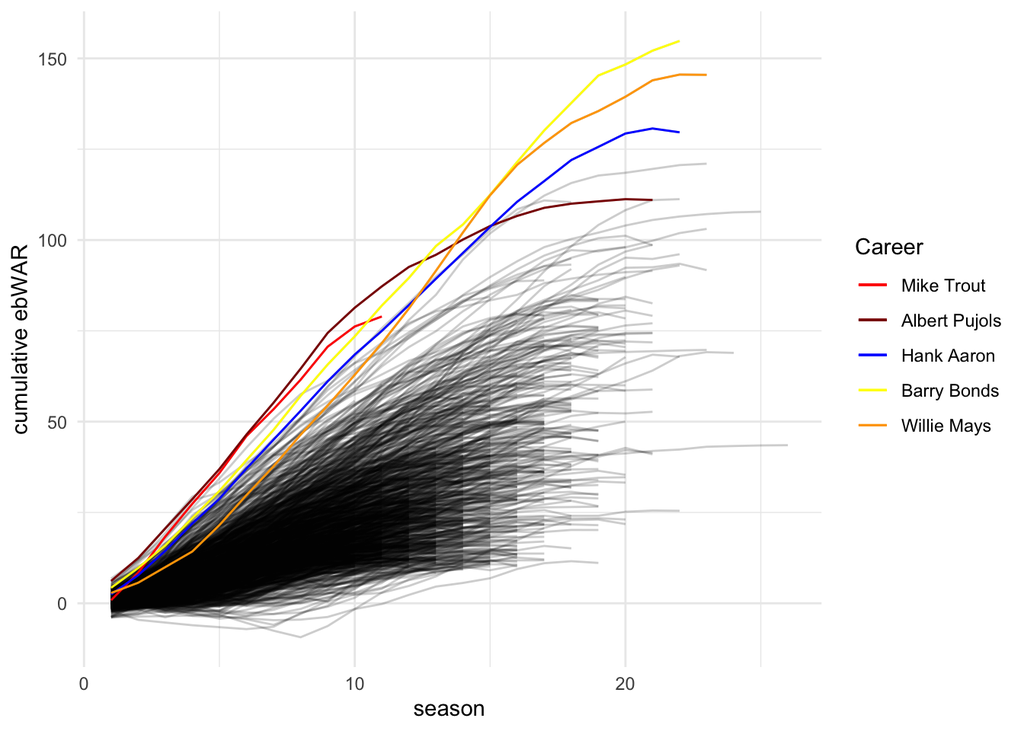

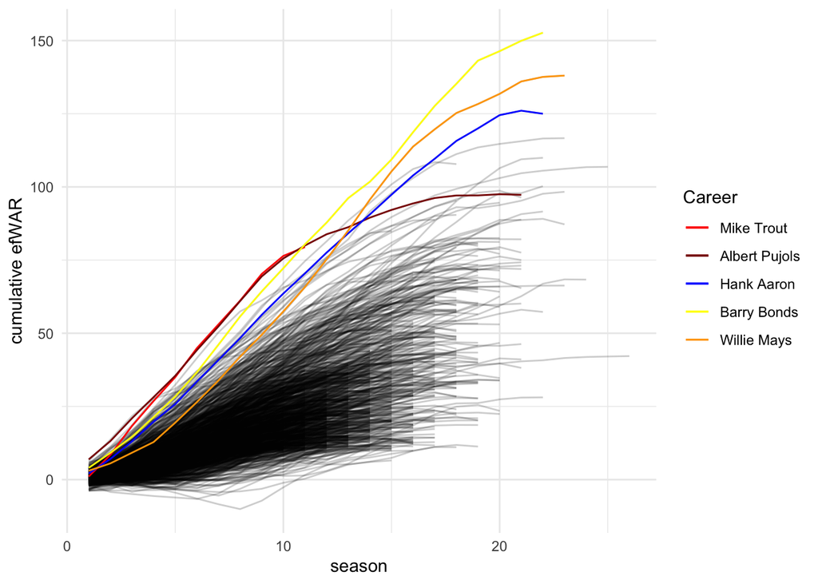

Here are Mike Trout’s other-worldy era-adjusted statistics. We see that Trout is already among the greatest of all-time.

| name | age | year | PA | AB | H | HR | BB | BA | OBP | ABpHR | ebWAR | efWAR | ebWARp100PA | efWARp100PA |
| --- | --- | --- | --- | --- | --- | --- | --- | --- | --- | --- | --- | --- | --- | --- |
| Mike Trout | 19 | 2011 | 178 | 95 | 25 | 9 | 10 | 0.263 | 0.343 | 10.56 | 0.85 | 1.05 | 0.48 | 0.59 |
| Mike Trout | 20 | 2012 | 644 | 535 | 176 | 31 | 86 | 0.329 | 0.423 | 17.26 | 7.59 | 7.41 | 1.18 | 1.15 |
| Mike Trout | 21 | 2013 | 726 | 563 | 188 | 34 | 124 | 0.334 | 0.456 | 16.56 | 9.91 | 9.86 | 1.37 | 1.36 |
| Mike Trout | 22 | 2014 | 717 | 582 | 182 | 45 | 92 | 0.313 | 0.409 | 12.93 | 9.03 | 8.54 | 1.26 | 1.19 |
| Mike Trout | 23 | 2015 | 463 | 463 | 145 | 26 | 80 | 0.313 | 0.421 | 17.81 | 8.46 | 8.14 | 1.83 | 1.76 |
| Mike Trout | 24 | 2016 | 686 | 496 | 162 | 28 | 114 | 0.327 | 0.458 | 17.71 | 10.17 | 9.90 | 1.48 | 1.44 |
| Mike Trout | 25 | 2017 | 512 | 368 | 121 | 26 | 98 | 0.329 | 0.474 | 14.15 | 7.39 | 8.14 | 1.44 | 1.59 |
| Mike Trout | 26 | 2018 | 613 | 442 | 149 | 36 | 108 | 0.337 | 0.473 | 12.28 | 8.13 | 8.10 | 1.33 | 1.32 |
| Mike Trout | 27 | 2019 | 619 | 432 | 129 | 33 | 128 | 0.299 | 0.471 | 13.09 | 9.10 | 9.12 | 1.47 | 1.47 |
| Mike Trout | 28 | 2020 | 644 | 535 | 159 | 36 | 97 | 0.297 | 0.405 | 14.86 | 5.56 | 6.17 | 0.86 | 0.96 |
| Mike Trout | 29 | 2021 | 213 | 117 | 41 | 12 | 36 | 0.350 | 0.510 | 9.75 | 2.75 | 3.03 | 1.29 | 1.42 |

**Career stats:**

| name | PA | AB | H | HR | BB | BA | OBP | ABpHR | ebWAR | efWAR | ebWARp100PA | efWARp100PA |
| --- | --- | --- | --- | --- | --- | --- | --- | --- | --- | --- | --- | --- |
| Mike Trout | 6015 | 4628 | 1477 | 316 | 973 | 0.319 | 0.442 | 14.65 | 78.94 | 79.46 | 1.31 | 1.32 |

A natural historic comparison for Mike Trout is Mickey Mantle. Both players are amazing all-around athletes, complete hitters, and play center field. Even one of Trout’s nicknames, the Millville Meteor, is an homage to Mantle’s nickname, the Commerce Comet. By raw, unadjusted, statistics Mickey Mantle is viewed as one of the greatest talents of all-time. Mike Trout has been better than Mickey Mantle so far by era-adjusted statistics.

**First 11 seasons aggregated:**

| name | PA | AB | H | HR | BB | BA | OBP | ABpHR | ebWAR | efWAR | ebWARp100PA | efWARp100PA |
| --- | --- | --- | --- | --- | --- | --- | --- | --- | --- | --- | --- | --- |
| Mickey Mantle | 6606 | 5277 | 1636 | 344 | 991 | 0.310 | 0.418 | 15.34 | 71.10 | 69.75 | 1.08 | 1.06 |
| Mike Trout | 6015 | 4628 | 1477 | 316 | 973 | 0.319 | 0.442 | 14.65 | 78.94 | 79.46 | 1.31 | 1.32 |

Maybe Willie Mays is a better comparison for Trout. Below, we see that Trout has been better on a rate basis, but perhaps Mays has been more productive overall.

**First 11 seasons aggregated:**

| name | PA | AB | H | HR | BB | BA | OBP | ABpHR | ebWAR | efWAR | ebWARp100PA | efWARp100PA |
| --- | --- | --- | --- | --- | --- | --- | --- | --- | --- | --- | --- | --- |
| Willie Mays | 6596 | 5565 | 1767 | 303 | 689 | 0.318 | 0.392 | 18.37 | 81.13 | 75.25 | 1.23 | 1.14 |
| Mike Trout | 6015 | 4628 | 1477 | 316 | 973 | 0.319 | 0.442 | 14.65 | 78.94 | 79.46 | 1.31 | 1.32 |

To catch Mays, Trout will have to stay healthy and productive. Here are Mays’ remaining era-adjusted seasons:

| name | PA | AB | H | HR | BB | BA | OBP | ABpHR | ebWAR | efWAR | ebWARp100PA | efWARp100PA |
| --- | --- | --- | --- | --- | --- | --- | --- | --- | --- | --- | --- | --- |
| Willie Mays | 5844 | 4770 | 1449 | 304 | 788 | 0.304 | 0.402 | 15.69 | 64.34 | 62.79 | 1.1 | 1.07 |

## Willie Stargell

When digging around the era-adjusted statistics, we found something rather exciting and unexpected. Willie Stargell currently ranks 6th all-time in era-adjusted home runs per adjusted at-bats (13.66) among players with at least 4000 adjusted at-bats. The people in front of him are Mark McGwire, Babe Ruth, Giancarlo Stanton, Barry Bonds, and Dave Kingman. The players immediately behind him are Willie McCovey and Mike Schmidt!

| name | PA | AB | H | HR | BB | BA | OBP | ABpHR | ebWAR | efWAR | ebWARp100PA | efWARp100PA |
| --- | --- | --- | --- | --- | --- | --- | --- | --- | --- | --- | --- | --- |
| Babe Ruth | 10596 | 7842 | 2293 | 706 | 1667 | 0.292 | 0.419 | 11.11 | 111.25 | 109.95 | 1.05 | 1.04 |
| Mark McGwire | 7453 | 5733 | 1518 | 485 | 1239 | 0.265 | 0.397 | 11.82 | 63.21 | 65.37 | 0.85 | 0.88 |
| Giancarlo Stanton | 5595 | 4514 | 1300 | 344 | 736 | 0.288 | 0.391 | 13.12 | 50.11 | 47.88 | 0.90 | 0.86 |
| Barry Bonds | 12362 | 9484 | 2869 | 714 | 2223 | 0.303 | 0.437 | 13.28 | 154.80 | 152.69 | 1.25 | 1.24 |
| Dave Kingman | 7527 | 6166 | 1499 | 456 | 666 | 0.243 | 0.319 | 13.52 | 21.19 | 24.88 | 0.28 | 0.33 |
| Willie Stargell | 8792 | 7186 | 2066 | 526 | 933 | 0.288 | 0.372 | 13.66 | 56.34 | 60.40 | 0.64 | 0.69 |
| Willie McCovey | 8820 | 6925 | 1991 | 493 | 1240 | 0.288 | 0.398 | 14.05 | 63.21 | 65.68 | 0.72 | 0.74 |
| Mike Schmidt | 10098 | 7992 | 2164 | 561 | 1521 | 0.271 | 0.388 | 14.25 | 110.43 | 107.80 | 1.09 | 1.07 |
| Nelson Cruz | 8156 | 6784 | 2009 | 468 | 878 | 0.296 | 0.380 | 14.50 | 56.35 | 55.86 | 0.69 | 0.68 |
| Harmon Killebrew | 8918 | 6999 | 1746 | 482 | 1453 | 0.249 | 0.379 | 14.52 | 55.17 | 58.11 | 0.62 | 0.65 |

We can see that Stargell was one of the most prolific power hitters of all-time when one takes into account the following facts: the extended pitching dominance in the 60s, the post-integration surge of players into the 1970s, and his long time home park Forbes Field was notoriously hard on left-handed batters. It is interesting to see what speculation was written about Stargell in the second to last paragraph of his [SABR bio](https://sabr.org/bioproj/person/willie-stargell/):

> At the time of his retirement, Stargell’s 475 home runs tied him with Stan Musial for 15th on the all-time list. As legendary a power hitter as he was, one is still tempted to ask, “What if?” What if he hadn’t played eight-and-a-half years in the home run graveyard of Forbes Field? What if his knees had held up? What if he had been more serious about staying in shape early in his career? Four-hundred-seventy-five home runs, of course, is an extraordinary achievement. But one could imagine how a consistently healthy, consistently fit Stargell shooting at a more inviting right field porch could have boosted that total to well over 500; maybe even, as he suggested himself, close to 600.

Our method has Stargell at 526 era-adjusted home runs when we project his career in to the context beginning in 1977, which, although 526 is still far from 600, it is easy to imagine that a healthy Stargell would be close to 600. If one were to project his stats into the launch angle and exit velolicity context of the current era (current at the time that this was written) then Stargell’s totals should be right around 600. So Willie Stargell got it right. He would hit close to 600 home runs, if he were consistently fit and moved to a more forgiving ball park. Willie Stargell is a casuality of the WAR movement and era-adjusted WAR does not revitalize his image. But we should think of Stargell as one of the most efficient and prolific home run hitters of all time. [This is the mental image](https://www.youtube.com/watch?v=XBeels-WDko&ab_channel=BarattaPartners) we should have in mind when we think of Willie Stargell.

## Max Scherzer

Max Scherzer is one of this era’s greatest pitchers. He is one of a handfull of pitchers to win 3 Cy Young awards. Other players with 3 Cy Young awards include Roger Clemens, Randy Johnson, Greg Maddux, Steve Carlton, Tom Seaver, Pedro Martinez, Clayton Kershaw, Sandy Koufax, and Jim Palmer. Scherzer’s run from 2013-2019 is especially dominant. Over that stretch he collected his Cy Young awards and never fell below fifth in the voting. That being said, his numbers over that stretch [do not leap off of the page](https://www.fangraphs.com/players/max-scherzer/3137/stats?position=P). Sure, his strikeout rates and strike outs per walk ratios are all-time elite, but ERA and most counting totals do not reflect the Cy Young voting when viewed from the lens of baseball history. Take Tom Seaver as an example. From 1969 to 1975 Terrific Tom boasted similar dominance and also collected 3 Cy Young awards. In 1971 Seaver had a 1.76 ERA over 286.1 innings. [Surely his run leaps off the page](https://www.fangraphs.com/players/tom-seaver/1011708/stats?position=P).

Max Scherzer’s dominance is punished by his era, a time period with a large MLB eligible talent pool, lower innings totals, and a balance of hitting and pitching that was [tilted in the favor of pitching](https://www.espn.com/mlb/story/_/id/12842711/mlb-hurlers-rise-dominance) which, in this case, led to a crowded field of low ERA totals. Our per season era-adjusted statistics paint a more favorable comparison of Scherzer’s dominant 7-year run from 2013-2019 to that of Seaver’s dominant run from 1969-1975:

| name | ERA | IP | K | K9 | ebWAR | efWAR | ebWARp100IP | efWARp100IP |
| --- | --- | --- | --- | --- | --- | --- | --- | --- |
| Max Scherzer | 2.66 | 1813 | 1850 | 9.2 | 54.20 | 47.06 | 2.99 | 2.60 |
| Tom Seaver | 2.59 | 1637 | 1405 | 7.7 | 45.61 | 38.98 | 2.79 | 2.38 |

As it currently stands, Max Scherzer ranks, respectively, 17th in career ebWAR and 22nd in career efWAR among pitchers and is among elite company:

| rank | name | ebWAR | rank | name | efWAR |
| --- | --- | --- | --- | --- | --- |
| 12 | Phil Niekro | 85.73 | 17 | Bob Gibson | 75.34 |
| 13 | Justin Verlander | 83.71 | 18 | Clayton Kershaw | 74.96 |
| 14 | Clayton Kershaw | 82.41 | 19 | CC Sabathia | 74.90 |
| 15 | Tom Glavine | 81.87 | 20 | Zack Greinke | 73.77 |
| 16 | Zack Greinke | 81.72 | 21 | John Smoltz | 73.39 |
| 17 | Max Scherzer | 81.24 | 22 | Max Scherzer | 73.09 |
| 18 | Gaylord Perry | 81.08 | 23 | Tom Glavine | 72.21 |
| 19 | Steve Carlton | 78.84 | 24 | Andy Pettitte | 71.85 |
| 20 | Bob Gibson | 77.31 | 25 | Fergie Jenkins | 71.71 |
| 21 | CC Sabathia | 76.64 | 26 | Kevin Brown | 71.52 |
| 22 | Roy Halladay | 75.25 | 27 | Pete Alexander | 70.10 |

As you see above, similar analyses can point out the dominance of Scherzer’s contemporaries: Clayton Kershaw, Justin Verlander, Zack Greinke, and CC Sabathia. Of the list above, only Clayton Kershaw ranks above Max Scherzer on a rate basis.

## CC Sabathia

Let’s go down the rabbit hole further and take a brief look at CC Sabathia’s illustrious career, and compare it to legendary pitchers Walter Johnson and Pete Alexander. We will consider Walter Johnson’s career from 1907-1925 and Alexander’s career from 1911-1929. The last few seasons of Johnson’s and Alexander’s career are trimmed due to our method projecting those seasons to be far below replacement to the point that they would likely be replaced.

| name | ERA | IP | K | K9 | ebWAR | efWAR | ebWARp100IP | efWARp100IP |
| --- | --- | --- | --- | --- | --- | --- | --- | --- |
| Walter Johnson | 3.27 | 4313 | 3401 | 7.1 | 90.27 | 86.46 | 2.09 | 2.00 |
| CC Sabathia | 3.16 | 3945 | 2870 | 6.5 | 76.65 | 74.90 | 1.94 | 1.90 |
| Pete Alexander | 3.47 | 4097 | 2481 | 5.5 | 64.87 | 70.10 | 1.58 | 1.71 |

What we can see from this is that CC Sabathia had a comparable career to Walter Johnson on a rate-basis, although Johnson was more productive overall, and he had a better career than Pete Alexander. We also see that CC Sabathia’s compares well to several great modern pitchers.

| name | ERA | IP | K | K9 | ebWAR | efWAR | ebWARp100IP | efWARp100IP |
| --- | --- | --- | --- | --- | --- | --- | --- | --- |
| Tom Glavine | 3.19 | 4540 | 2569 | 5.1 | 81.91 | 72.21 | 1.80 | 1.59 |
| Max Scherzer | 2.81 | 3131 | 2982 | 8.6 | 81.24 | 73.09 | 2.59 | 2.33 |
| CC Sabathia | 3.16 | 3945 | 2870 | 6.5 | 76.65 | 74.90 | 1.94 | 1.90 |
| Fergie Jenkins | 3.38 | 3975 | 2944 | 6.7 | 72.95 | 71.71 | 1.84 | 1.80 |
| Don Sutton | 3.95 | 4721 | 3275 | 6.2 | 66.98 | 77.18 | 1.42 | 1.63 |

Some day in the future, CC Sabathia and Max Scherzer will be in the Hall of Fame.

## The Babe Ruth anomaly

Babe Ruth revolutionized baseball by prioritizing home run hitting as the MLB livened the baseball. As [stated here](https://www.tandfonline.com/doi/full/10.1080/09332480.2020.1726114), the single season home run record before Babe Ruth was 27 by Ned Williamson in 1884. Babe Ruth broke this record in 1919 when he hit 29 home runs. He subsequently destroyed his own record in the following 1920 season when he hit 54 home runs. The runner up in 1920 finished the season with only 15 home runs. This level of dominance has never been seen before and has never been seen since, and it poses a problem for era-adjustment techniques.

**Babe Ruth’s dominance is in part due to his talent, but is also in part to him exercising a superior batting strategy that had not existed before.** Therefore, Ruth’s “vs his peers” stats are slightly distorted, and his era-adjusted stats will also be distorted as a result. Ruth’s era-adjusted stats reflect the combination of his talent and his competitive advantage. This competitive advantage does not exist in other contexts. Our method will therefore overestimate Ruth’s era-adjusted home run hitting and his era-adjusted WAR since our method does not yet disentangle talent and competitive circumstance. The problem of the Babe Ruth anomaly confounds all era-adjustment techniques. We imagine that Ruth’s era-adjusted OBP is also overestimated by our method. The Babe Ruth anomaly challenges all other era-adjustment techniques, and is especially challenging for anyone making interpretations based solely on raw or league adjusted “+” stats.

## The Tony Gwynn anomaly

Tony Gwynn has the highest era-adjusted batting average by a mile (See part I). He was a truly amazing hitter who stood very far from his peers. However, like Babe Ruth, a portion of his dominance is due to circumstance. Gywnn was one of the [early pioneers of using film to study](https://bleacherreport.com/articles/2099278-we-remember-tony-gwynn-pioneers-video-analysis-for-players-on-his-vcr) his strengths and weaknesses as well as the strengths and weaknesses of the pitchers that he faced. Nowadays film study is a basic training method available to everyone in the MLB, and it is unusual and [worth mentioning](http://www.espn.com/espn/feature/story/_/id/10619342/creative-control-clayton-kershaw-abides-strict-code) when great players do not use it. Therefore, like Ruth, Gwynn’s batting average stats are slightly distorted, and his era-adjusted stats will also be distorted as a result. Like Ruth, Gwynn’s era-adjusted stats reflect the combination of his talent and his competitive advantage. Our method will therefore overestimate Gwynn’s era-adjusted batting average and his era-adjusted WAR as a result.

## WAR and it’s usage in HOF discussions

One of the goals of WAR is to provide a framework for people like us to compare players across eras. The following passage is taken directly from the [What is WAR? page on FanGraphs](https://library.fangraphs.com/misc/war/): **“The goal of WAR is to provide a holistic metric of player value that allows for comparisons across team, league, year, and era and a framework for player evaluation.”**

The work in this article moves WAR closer to its goal of providing fair comparisons of players who have played in vastly different eras. This matters when we evaluate a player’s career in historical context. **The HOF players of the old past are beneficiaries of biased performance metrics.** Comparisons based upon “vs your peers” statistics are therefore slanted in favor of old time players—specifically those who performed in the segregated NL/AL. With the Full House Model, this is no more. Here is a look at players who are not in the HOF, but have era-adjusted bWAR and fWAR values in the top 100 at the time that this was written:

| rank | name | ebWAR | rank | name | efWAR |
| --- | --- | --- | --- | --- | --- |
| 1 | Barry Bonds | 154.80 | 1 | Barry Bonds | 152.69 |
| 3 | Roger Clemens | 141.78 | 3 | Roger Clemens | 131.18 |
| 6 | Alex Rodriguez | 121.01 | 6 | Alex Rodriguez | 116.66 |
| 8 | Albert Pujols | 111.03 | 14 | Albert Pujols | 97.29 |
| 13 | Adrian Beltre | 98.70 | 23 | Adrian Beltre | 88.84 |
| 31 | Curt Schilling | 86.64 | 36 | Miguel Cabrera | 80.77 |
| 36 | Justin Verlander | 83.71 | 40 | Justin Verlander | 79.62 |
| 39 | Miguel Cabrera | 83.16 | 41 | Mike Trout | 79.46 |
| 41 | Clayton Kershaw | 82.41 | 44 | Carlos Beltran | 78.75 |
| 42 | Carlos Beltran | 82.00 | 47 | Curt Schilling | 77.36 |
| 44 | Zack Greinke | 81.72 | 49 | Pete Rose | 77.12 |
| 45 | Max Scherzer | 81.24 | 51 | Scott Rolen | 75.75 |
| 49 | Robinson Cano | 79.95 | 54 | Clayton Kershaw | 74.96 |
| 54 | Mike Trout | 78.94 | 55 | CC Sabathia | 74.90 |
| 56 | Scott Rolen | 78.46 | 56 | Andruw Jones | 74.89 |
| 57 | Pete Rose | 78.41 | 59 | Zack Greinke | 73.77 |
| 58 | Kenny Lofton | 78.33 | 61 | Manny Ramirez | 73.36 |
| 62 | CC Sabathia | 76.64 | 63 | Max Scherzer | 73.09 |
| 64 | Manny Ramirez | 76.07 | 68 | Ichiro Suzuki | 71.89 |
| 65 | Ichiro Suzuki | 75.87 | 69 | Andy Pettitte | 71.85 |
| 67 | Joey Votto | 75.47 | 73 | Rafael Palmeiro | 71.45 |
| 70 | Lou Whitaker | 75.18 | 76 | Joey Votto | 70.43 |
| 72 | Chase Utley | 74.57 | 77 | Chase Utley | 70.31 |
| 76 | Andy Pettitte | 74.19 | 80 | Kenny Lofton | 69.60 |
| 77 | Rafael Palmeiro | 73.84 | 81 | Robinson Cano | 69.33 |
| 89 | Bobby Grich | 71.22 | 88 | Bobby Grich | 68.25 |
| 92 | Bobby Abreu | 70.47 | 89 | Lou Whitaker | 68.14 |
| 93 | Andruw Jones | 70.22 | 94 | Bobby Abreu | 67.05 |

## Todd Helton

An analysis based on our method says that: “With all facets of his game taken together including era, Helton’s 73.18 career ebWAR is 9th among first basemen, and below 4 of the 21 enshrined including Bagwell, Thome, and Thomas, whose careers overlapped with his. Helton’s 73.18 ebWAR ranks 53rd all-time among batters and 78th overall.”

For reference, the only first basemen currently ranking in front of Helton are Albert Pujols, Jeff Bagwell, Miguel Cabrera, Frank Thomas, Lou Gehrig, Jim Thome, Joey Votto, and Rafael Palmeiro. Their careers are depicted below along with the other first basemen comprising the top 100 hitters in career ebWAR:

| rank | name | PA | AB | H | HR | BB | BA | OBP | ABpHR | ebWAR | efWAR | ebWARp100PA | efWARp100PA |
| --- | --- | --- | --- | --- | --- | --- | --- | --- | --- | --- | --- | --- | --- |
| 6 | Albert Pujols | 12415 | 10628 | 3315 | 660 | 1474 | 0.312 | 0.398 | 16.10 | 111.03 | 97.29 | 0.89 | 0.78 |
| 22 | Jeff Bagwell | 9438 | 7669 | 2297 | 419 | 1343 | 0.300 | 0.408 | 18.30 | 84.30 | 84.95 | 0.89 | 0.90 |
| 26 | Miguel Cabrera | 10937 | 9375 | 2991 | 500 | 1368 | 0.319 | 0.406 | 18.75 | 83.16 | 80.77 | 0.76 | 0.74 |
| 32 | Frank Thomas | 9862 | 7869 | 2409 | 474 | 1589 | 0.306 | 0.423 | 16.60 | 79.53 | 76.38 | 0.81 | 0.77 |
| 34 | Lou Gehrig | 9481 | 7565 | 2235 | 432 | 1244 | 0.295 | 0.398 | 17.51 | 79.18 | 79.04 | 0.84 | 0.83 |
| 41 | Jim Thome | 9758 | 7691 | 2159 | 517 | 1681 | 0.281 | 0.411 | 14.88 | 77.08 | 73.10 | 0.79 | 0.75 |
| 46 | Joey Votto | 8383 | 6575 | 2047 | 306 | 1441 | 0.311 | 0.437 | 21.49 | 75.47 | 70.43 | 0.90 | 0.84 |
| 52 | Rafael Palmeiro | 11673 | 9939 | 2874 | 498 | 1338 | 0.289 | 0.374 | 19.96 | 73.84 | 71.45 | 0.63 | 0.61 |
| 53 | Todd Helton | 9151 | 7379 | 2170 | 299 | 1340 | 0.294 | 0.402 | 24.68 | 73.18 | 64.92 | 0.80 | 0.71 |
| 68 | Eddie Murray | 12632 | 10892 | 3198 | 510 | 1328 | 0.294 | 0.368 | 21.36 | 69.48 | 72.98 | 0.55 | 0.58 |
| 83 | Jimmie Foxx | 9149 | 7416 | 1995 | 451 | 1141 | 0.269 | 0.367 | 16.44 | 65.05 | 70.72 | 0.71 | 0.77 |
| 88 | Willie McCovey | 8820 | 6925 | 1991 | 493 | 1240 | 0.288 | 0.398 | 14.05 | 63.21 | 65.68 | 0.72 | 0.74 |
| 89 | Mark McGwire | 7453 | 5733 | 1518 | 485 | 1239 | 0.265 | 0.397 | 11.82 | 63.21 | 65.37 | 0.85 | 0.88 |
| 95 | Fred McGriff | 10056 | 8422 | 2407 | 446 | 1292 | 0.286 | 0.380 | 18.88 | 62.27 | 64.96 | 0.62 | 0.65 |
| 97 | John Olerud | 8945 | 7301 | 2181 | 255 | 1254 | 0.299 | 0.403 | 28.63 | 61.72 | 62.09 | 0.69 | 0.69 |
| 98 | Keith Hernandez | 8504 | 6984 | 2081 | 193 | 1108 | 0.298 | 0.393 | 36.19 | 61.66 | 60.10 | 0.73 | 0.71 |

We hope that Jaffe and others will consider our approach when they discuss a players HOF candidacy. Our era-adjusted statistics demonstrate a dramatic reranking of players which is important for HOF discussions, especially for post-integration and more modern players.

## Mark Buehrle

Let’s turn our focus to the HOF candidacy of another player, Mark Buehrle. Our era-adjusted versions of WAR are very favorable to Buerhle’s career and he should be a sure-fire Hall of Famer. He ranks 74th in career ebWAR and 119th in career efWAR. Here is a brief list of currently unquestioned Hall of Fame pitchers that Buehrle exceeds in both these totals and on a rate basis:

| name | ERA | IP | K | K9 | ebWAR | efWAR | ebWARp100IP | efWARp100IP |
| --- | --- | --- | --- | --- | --- | --- | --- | --- |
| Mark Buehrle | 3.16 | 3684 | 1988 | 4.9 | 74.34 | 62.32 | 2.02 | 1.69 |
| Warren Spahn | 3.74 | 4524 | 2505 | 5.0 | 72.84 | 55.29 | 1.61 | 1.22 |
| Robin Roberts | 3.83 | 4186 | 2272 | 4.9 | 72.01 | 59.21 | 1.72 | 1.41 |
| Jim Palmer | 3.12 | 3464 | 2210 | 5.7 | 63.68 | 51.50 | 1.84 | 1.49 |
| Whitey Ford | 2.99 | 2985 | 1929 | 5.8 | 50.83 | 49.22 | 1.70 | 1.65 |
| Tim Keefe | 3.35 | 2577 | 1700 | 5.9 | 41.64 | 39.92 | 1.62 | 1.55 |

Mark Buehrle also has a World Series ring and two no-hitters, including a perfect game, to complement a career that according to era-adjusted WAR has been better than Warren Spahn, Robin Roberts, Jim Palmer, Whitey Ford, and Tim Keefe. So, besides not having an era-adjustment tool until now, what is the knock against him? It seems that Buehrle is viewed as a durable compiler. The issue against Buehrle is that he was a [durable compiler](https://www.overtimeheroics.net/2021/03/05/mlb-history-mark-buehrle/) during a period in which pitching usage is much less than past eras. Thus, his innings totals did not really amount to anything impressive. However, when you compare innings “vs your peers” then this story changes. Buehrle’s era-adjusted 3684 innings ranks 27th all-time!

## Luis Tiant

Tiant spent 15 years on the BBWAA ballot and was never particularly close to the 75% voting threshold that was needed for HOF inclusion. He also was not very close to HOF inclusion when his name appeared on the ballot of various Veterans Committees. We would like to revisit Tiant’s HOF case here. By ebWAR and efWAR Tiant ranks as the 45th and 66th best pitcher in history and ranks 143 and 209 overall among both pitchers and hitters by, respectively, ebWAR and efWAR. There are currently 278 former MLB players in the HOF. If we included players based on stats, then Tiant would be in.

Let’s compare Tiant to the same group with which we compared Buehrle. Among this group, Tiant ranks 1st and 2nd according to, respectively ebWAR per 100 IP and efWAR per 100 IP, and ranks 4th in career eWAR. This is a reflection of his greatness and injuries which cut his career short. Tiant is the most prolific strikeout pitcher among this group and his era-adjusted ERA ranks 4th.

| name | ERA | IP | K | K9 | ebWAR | efWAR | ebWARp100IP | efWARp100IP |
| --- | --- | --- | --- | --- | --- | --- | --- | --- |
| Warren Spahn | 3.74 | 4524 | 2505 | 5.0 | 72.84 | 55.29 | 1.61 | 1.22 |
| Robin Roberts | 3.83 | 4186 | 2272 | 4.9 | 72.01 | 59.21 | 1.72 | 1.41 |
| Jim Palmer | 3.12 | 3464 | 2210 | 5.7 | 63.68 | 51.50 | 1.84 | 1.49 |
| Luis Tiant | 3.39 | 3158 | 2304 | 6.6 | 61.05 | 51.60 | 1.93 | 1.63 |
| Whitey Ford | 2.99 | 2985 | 1929 | 5.8 | 50.83 | 49.22 | 1.70 | 1.65 |
| Tim Keefe | 3.35 | 2577 | 1700 | 5.9 | 41.64 | 39.92 | 1.62 | 1.55 |

Tiant should be regarded as a sure-fire HOFer by this analysis. He was also a great postseason pitcher when his team made the postseason. So why isn’t Luis Tiant in the HOF? One reason may be that he had bad luck on the ballot and had to repeatedly compete with pitchers who had longer careers and won 300 games. Let’s look at how Luis Tiant stacks up against the mythical 300 win club. This is a tough group and Tiant is on the bottom end, but not at the bottom, by career eWAR. However, on a rate basis he was more productive than the median pitcher in this group by ebWAR and was slightly lower than the median pitcher in this group by efWAR. Here is the 300 win club plus Luis Tiant organized by ebWAR per 100 IP:

| name | IP | ER | ERA | K | K9 | ebWAR | efWAR | ebWARp100IP | efWARp100IP |
| --- | --- | --- | --- | --- | --- | --- | --- | --- | --- |
| Roger Clemens | 5062 | 1666 | 2.96 | 4453 | 7.9 | 141.78 | 131.18 | 2.80 | 2.59 |
| Lefty Grove | 3533 | 1326 | 3.38 | 2432 | 6.2 | 87.67 | 83.52 | 2.48 | 2.36 |
| Randy Johnson | 4326 | 1468 | 3.05 | 4562 | 9.5 | 105.31 | 100.63 | 2.43 | 2.33 |
| Tom Seaver | 4324 | 1497 | 3.12 | 3329 | 6.9 | 98.16 | 83.41 | 2.27 | 1.93 |
| Greg Maddux | 5250 | 1753 | 3.01 | 3444 | 5.9 | 111.58 | 115.29 | 2.13 | 2.20 |
| Walter Johnson | 4543 | 1762 | 3.49 | 3537 | 7.0 | 88.90 | 86.30 | 1.96 | 1.90 |
| Phil Niekro | 4406 | 1684 | 3.44 | 3122 | 6.4 | 85.73 | 66.90 | 1.95 | 1.52 |
| Kid Nichols | 3196 | 1164 | 3.28 | 1996 | 5.6 | 62.27 | 56.61 | 1.95 | 1.77 |
| Luis Tiant | 3158 | 1189 | 3.39 | 2304 | 6.6 | 61.06 | 51.60 | 1.93 | 1.63 |
| Cy Young | 4794 | 1843 | 3.46 | 2959 | 5.6 | 87.09 | 91.41 | 1.82 | 1.91 |
| Tom Glavine | 4540 | 1609 | 3.19 | 2569 | 5.1 | 81.87 | 72.21 | 1.80 | 1.59 |
| Steve Carlton | 4436 | 1657 | 3.36 | 3924 | 8.0 | 78.84 | 86.10 | 1.78 | 1.94 |
| Gaylord Perry | 4624 | 1867 | 3.63 | 3169 | 6.2 | 81.08 | 89.08 | 1.75 | 1.93 |
| Christy Mathewson | 3556 | 1334 | 3.38 | 2269 | 5.7 | 62.20 | 63.68 | 1.75 | 1.79 |
| Pud Galvin | 2788 | 1079 | 3.48 | 1762 | 5.7 | 45.21 | 41.59 | 1.62 | 1.49 |
| Tim Keefe | 2577 | 961 | 3.36 | 1700 | 5.9 | 41.64 | 39.92 | 1.62 | 1.55 |
| Warren Spahn | 4524 | 1880 | 3.74 | 2505 | 5.0 | 72.86 | 55.29 | 1.61 | 1.22 |
| Old Hoss Radbourn | 2206 | 820 | 3.35 | 1304 | 5.3 | 35.59 | 31.49 | 1.61 | 1.43 |
| Pete Alexander | 4097 | 1580 | 3.47 | 2481 | 5.5 | 64.88 | 70.10 | 1.58 | 1.71 |
| Mickey Welch | 2352 | 903 | 3.46 | 1419 | 5.4 | 36.44 | 32.00 | 1.55 | 1.36 |
| Nolan Ryan | 4952 | 2066 | 3.75 | 5678 | 10.3 | 75.08 | 105.23 | 1.52 | 2.12 |
| Eddie Plank | 3355 | 1343 | 3.60 | 2078 | 5.6 | 50.49 | 48.87 | 1.50 | 1.46 |
| John Clarkson | 2330 | 922 | 3.56 | 1391 | 5.4 | 34.57 | 36.16 | 1.48 | 1.55 |
| Don Sutton | 4721 | 2070 | 3.95 | 3275 | 6.2 | 66.99 | 77.18 | 1.42 | 1.63 |
| Early Wynn | 4070 | 2197 | 4.86 | 2396 | 5.3 | 17.02 | 26.16 | 0.42 | 0.64 |

Here is a brief list of currently unquestioned Hall of Fame pitchers and 300 game winners that Tiant exceeds in both eWAR totals and on a rate basis:

| name | IP | ER | ERA | K | K9 | ebWAR | efWAR | ebWARp100IP | efWARp100IP |
| --- | --- | --- | --- | --- | --- | --- | --- | --- | --- |
| Luis Tiant | 3158 | 1189 | 3.39 | 2304 | 6.6 | 61.06 | 51.60 | 1.93 | 1.63 |
| Eddie Plank | 3355 | 1343 | 3.60 | 2078 | 5.6 | 50.49 | 48.87 | 1.50 | 1.46 |
| Pud Galvin | 2788 | 1079 | 3.48 | 1762 | 5.7 | 45.21 | 41.59 | 1.62 | 1.49 |
| Tim Keefe | 2577 | 961 | 3.36 | 1700 | 5.9 | 41.64 | 39.92 | 1.62 | 1.55 |
| Mickey Welch | 2352 | 903 | 3.46 | 1419 | 5.4 | 36.44 | 32.00 | 1.55 | 1.36 |
| Old Hoss Radbourn | 2206 | 820 | 3.35 | 1304 | 5.3 | 35.59 | 31.49 | 1.61 | 1.43 |
| John Clarkson | 2330 | 922 | 3.56 | 1391 | 5.4 | 34.57 | 36.16 | 1.48 | 1.55 |
| Early Wynn | 4070 | 2197 | 4.86 | 2396 | 5.3 | 17.02 | 26.16 | 0.42 | 0.64 |

## Joe Posnanski’s Baseball 100

Recently Joe Posnanski produced a [book of the 100 greatest players of all time](https://www.simonandschuster.com/books/The-Baseball-100/Joe-Posnanski/9781982180584). This book is elegant in its presentation and is a tour-de-force of great anecdotes, and it is an impressive achievement to have devised such an overall great list without advanced statistical methodology. While at the Athletic, [Posnanski had this to say](https://theathletic.com/1457115/2019/12/17/the-baseball-100-a-project-celebrating-the-greatest-players-in-history/) about his philosophy on ranking lists of these sort: Some of it is science, but admittedly some of it also art. I [Joe Posnanski] will give you a handful of guiding principles:

> 1. I think today’s players tend to be underrated compared to those who came before them.
> 2. I lean toward players who were great at their peak, even if that peak only lasted a short time, and lean away from those who were consistently but not toweringly good for a long time.
> 3. I lean toward players who did multiple things well over specialists (no matter how great) who basically did just one thing well.
> 4. I take a lot of care to make educated guesses about players whose careers were shortened by things beyond their control – World War II, for example, or baseball’s tragic and infuriating color line. I don’t make the same adjustment for injuries. As Bill James has written, there’s a big difference. The years when Joe DiMaggio or Ted Williams or Bob Feller were at war, the years when Josh Gibson and Oscar Charleston played in the Negro Leagues, they were still the best players on earth. They just couldn’t play in the big leagues because of larger issues. When players get hurt – take Don Mattingly, for example, and his back problems – they stop being the best players in the world. I wish Donnie Baseball didn’t get hurt, we all do, but he did, and he was never quite the same player after that. That’s not the same as saying that Bob Feller lost four years when he was still the best pitcher on earth.

We provide Posnanski’s top 25 NL/AL players of all-time along with our top 25 NL/AL players ranked by era-adjusted bWAR and era-adjusted fWAR.

| rank | Posnanski’s NL/AL rankings | ebWAR | efWAR |
| --- | --- | --- | --- |
| 1 | Willie Mays | Barry Bonds | Barry Bonds |
| 2 | Babe Ruth | Willie Mays | Willie Mays |
| 3 | Barry Bonds | Roger Clemens | Roger Clemens |
| 4 | Hank Aaron | Henry Aaron | Henry Aaron |
| 5 | Ted Williams | Babe Ruth | Babe Ruth |
| 6 | Walter Johnson | Alex Rodriguez | Alex Rodriguez |
| 7 | Ty Cobb | Greg Maddux | Greg Maddux |
| 8 | Stan Musial | Albert Pujols | Mike Schmidt |
| 9 | Mickey Mantle | Mike Schmidt | Rickey Henderson |
| 10 | Honus Wagner | Rickey Henderson | Nolan Ryan |
| 11 | Roger Clemens | Randy Johnson | Randy Johnson |
| 12 | Lou Gehrig | Stan Musial | Ted Williams |
| 13 | Alex Rodriguez | Adrian Beltre | Stan Musial |
| 14 | Rogers Hornsby | Cal Ripken Jr. | Albert Pujols |
| 15 | Tris Speaker | Tom Seaver | Cal Ripken Jr. |
| 16 | Mike Schmidt | Frank Robinson | Mickey Mantle |
| 17 | Frank Robinson | Ted Williams | Frank Robinson |
| 18 | Joe Morgan | Mickey Mantle | Joe Morgan |
| 19 | Lefty Grove | Wade Boggs | Cy Young |
| 20 | Albert Pujols | Joe Morgan | Bert Blyleven |
| 21 | Rickey Henderson | Roberto Clemente | Wade Boggs |
| 22 | Pete Alexander | Ty Cobb | Gaylord Perry |
| 23 | Mike Trout | Ken Griffey Jr. | Adrian Beltre |
| 24 | Randy Johnson | Mike Mussina | Eddie Mathews |
| 25 | Eddie Collins | Chipper Jones | Chipper Jones |

We appreciate that Posnanski used an artistic as well as a scientific process to come up with the above rankings, and we appreciate the thinking that today’s players are underrated compared to those who came before them. And we appreciate that Posnanski placed Willie Mays in front of Babe Ruth! We applaud Posnanski’s effort to include great Negro League players in the upper echelon of his rankings, and we think that he has progressed the conversation on the greatness of Negro League players forward. For reference, Posnanski had Oscar Charleston at #5, Satchel Paige at #10, Josh Gibson at #15, and Pop Lloyd at #25. We removed these players from consideration so that we can make an apples-to-apples comparison between his methodology and our methodology, and we apologize to Posnanski because removing these names changes his list in a way that lowers its artistic value. All-in-all this ranking list is a great achievement.

Now come our criticisms. Whatever reasoning led to putting Willie Mays ahead of Babe Ruth should have also placed Rickey Henderson ahead of Ty Cobb, Albert Pujols ahead of Lou Gehrig, Cal Ripken Jr. ahead of Honus Wagner, and both Randy Johnson and Greg Maddux ahead of Walter Johnson.

We also observe that Posnanski’s list contains 6 NL/AL players who began their career before integration in his top 10 list, and 12 such players who began their career before integration in his top 25 list. By our calculations, the chance of observing 12 or more pre-integration players in a top 25 list is around 1 in 1000, and the chance of observing 6 or more pre-integration players in a top 10 list is around 1 in 200. Thus, Posnanski has included too many old time players in his rankings of the greatest all-time players despite his efforts to not do this.

## Comparing a Player Outside His Era: Bill James and Tom Tango

[Bill James published a fascinating conversation between Tom Tango and himself on the subject of cross-era comparisons.](https://www.billjamesonline.com/comparing_a_player_outside_his_era/) There are many nuggets from this conversation which deserve attention, but in the interest of brevity, we will only focus on a few segments.

Simplifying a little, Tom Tango’s initial position is that we should only compare players to their contemporaries in the strictest of senses. He says:

> You have about 12-15 nonpitcher in the HOF for any 10-11 year time period. If Andruw Jones [a player whose HOF candidcay that Bill and Tom are discussing] is one of the top 12 nonpitcher among his peers, great. If he’s one of the 40 nonpitchers born 1962-1992, great. (Though these numbers can be argued based on expansion.)… This way, we don’t have to make “timeline” adjustments. That’s me though.

Bill’s response is very lengthy (although not as lengthy as what you have read here). One of his main points of response is:

> Yes, of course it is difficult to make cross-generational comparisons in baseball, but you ignore the fact that we have a constant frame of reference which applies across time and which stabilizes the data across time: Wins. IF you can state a player’s contribution to his team in terms of wins and losses, then you have a valid basis for comparing a player from 1968 to a player in 2008—leaving only the large problem of the relative quality of play over time, and the relatively small issues of the length of the schedule and what to do with post-season play.

> And, in fact, we HAVE 85% solved the problem(s) of stating a player’s contribution to his team in terms of wins and losses. Yes, we still have the WAR/Wins and Losses Issue and the many problems inherent in WAR, but what we DO know about this issue now is much larger than what we do not know—unlike 1975, when we had not even reached the understanding that we needed to state these contributions in constant terms, and that wins was the constant unit which guides the debate.

Tom responds with:

> Inherent in the wins-as-the-great-equalizer debate is that it treats winning percentage of .500 as a constant. This forces a specific mindset: (a) do you adjust this across time, so that a .500 win% in 1917 is not the same as in 2017? (b) do you accept it is the same, solely for the purposes of peer-comparisons?

> If you accept (b), we’re holding the players accountable to their era only. And so any comparison of Ty Cobb to Rickey Henderson is limited to their comparisons to their direct peers, and then players of the early 1900s, as a group, are being treated as equals to the players of the 1980s and of today (.500 = .500). So, we’re actually comparing Cobb and Rickey through this “common baseline”.

> If you accept (a), you need to accept that players have gotten better across time, just like in every other sport, and so, the average player in Cobb’s time would likely be a bench player today, at best. I say this not only because players must have gotten physically stronger and faster, but also because 3/8ths of the best players today would have been precluded from playing during the segregation era. If we use players of the 1900s as any kind of benchmark, by this assumption, we’d be voting in ten players every year.

> In my view, before we jump through the hoops that a careful timeline comparison would require, (including establishing which of the two assumptions to follow, of which no one will agree with anyway) let’s at least do the easy part and compare players to their direct peers.

We are now going to interject ourselves into this conversation. **In our view, the Full House Model IS the careful timeline comparison sought by Tom Tango, and it renders his mindset distinctions between (a) and (b) moot.** The Full House Model takes statistics like WAR and corrects for its existing era-biases through a balancing of how one performs “vs their peers” and how many people are eligible to play in the MLB.

Tom is right when he suggests that we would be voting in more players every year if we actually approach HOF candidates by their era-adjusted talent. It seems that he is stating this as a drawback which, if true, would be very disappointing considering that older players’ statistics are inflated as a result of racial segregation.

## ESPN’s Top 100 MLB players of all time, Buster Olney and Christina Kahrl

In February 2022, [ESPN published a new top 100 ranking list](https://www.espn.com/mlb/story/_/id/33145121/top-100-mlb-players-all). Their list was compiled in essentially two steps. As quoted from the linked article:

> First, they selected a pool of 200 candidate players using career WAR, Hall of Fame status, peak performance and overall contributions to the game as initial screening criteria. They then asked dozens of ESPN editors and writers to contribute to a balloting system that pits players from the list against each other in head-to-head voting. The question they posed: “Based on a combination of career value and peak performance, which player would you rank higher?” ESPN’s participants voted more than 20,000 times. Based on those votes, the players were ranked by the percentage of the time they were chosen over any competing player.

The ESPN top 100 list included 6 players who began their career before baseball was integrated in their top 10, and 11 such players in their top 25. By our calculations, the chance of observing 11 or more pre-integration players in a top 25 list is around 1 in 250, and the chance of observing 6 or more pre-integration players in a top 10 list is around 1 in 200. Thus, ESPN has [yet again](https://www.espn.com/mlb/feature/video/_/id/8652210/espn-hall-100-ranking-all-greatest-mlb-players) included too many old time players in their rankings of the greatest all-time players.

One redeeming aspect about ESPN’s list is the discussion between Olney, Doolittle, Keown, Passan, Schoenfield, and Gonzalez that was published shortly after their list was released. Buster Olney started every round with all-around great takes regarding NL/AL players, and many others provided several additional great takes concerning such players while Passan was clearly drunk on nostalgia: “bUT RuTh Is A gUy WhO hIt MoRe HoMeRuNs ThAn EnTiRe TeAmS,” yawn. We especially appreciated how Olney started the show with his answer to the question: “What is the No. 1 thing that stands out to you when looking at our top 100?”

> That there are too many players from past eras dominating this list – which is a function of how well baseball statistics translate over generations. That’s fun… but there are too many George Mikans mixed in with the LeBrons, so to speak, in a sport that has evolved just as much as the NBA or the NFL.

In a [previous article](https://community.fangraphs.com/challenging-war-and-other-statistics-as-era-adjustment-tools/) Eck stated: “Superior statistical accomplishments achieved by players who started their careers way back in the day are a reflection of the inability to properly compare talent across eras.” Thank you Buster Olney! Olney and others’ reminds us of [Christina Kahrl’s excellent 2016 article](https://www.espn.com/mlb/story/_/page/mlbrank100_wagnergehrig/mlbrank-exploring-greatness-honus-wagner-lou-gehrig) on problems with using poorly calibrated “vs your peers” statistics to compare players across eras. Specifically, she said:

> The Gehrig and Wagner arguments boil down to this: Via WAR or OPS+ or your own understanding of all of the numbers we have, you have faith in our measuring their relative extraordinary superiority over their peers in smaller leagues with deliberate personnel limitations and an uneven distribution of talent. You can have that faith, and it relies on a lot of data for support – at the same time that you turn a blind eye to what’s going on in the game that creates that data.

This is a point that is routinely missed among baseball fans and analysts alike, in part because they have been duped by websites claiming that the metrics they use are era-adjusted. Perhaps these people prefer a simple black and white world where, for example, 80+ WAR means you’re a Hall of Famer. Or perhaps, they are simply not willing to grapple with what the difficulties of what “era-adjusted” ought to mean. In short, **for a metric to be era-adjusted it needs to account for the changing distributions of league statistics and the changing composition of MLB players.** The plot below depicts the WAR of a 2021 hypothetical replacement level batter (0 WAR) projected into every past season, the major shifts correspond to the integration of baseball and WWII, and the influx of Asian players in the mid-1990s. It is of interest to note that a replacement level player in 2021 is projected to produce about 3 WAR before 1950 (the really old seasons have fewer games). Thus the baseline quantity for which players are judged, the replacement player is a moving target that is getting better over time. It is interesting to note that the plot below aesthetically resembles a zoomed-out version of Stephen Jay Gould’s [punctuated equilibrium applied to changes in the fossil record.](https://en.wikipedia.org/wiki/Punctuated_equilibrium)

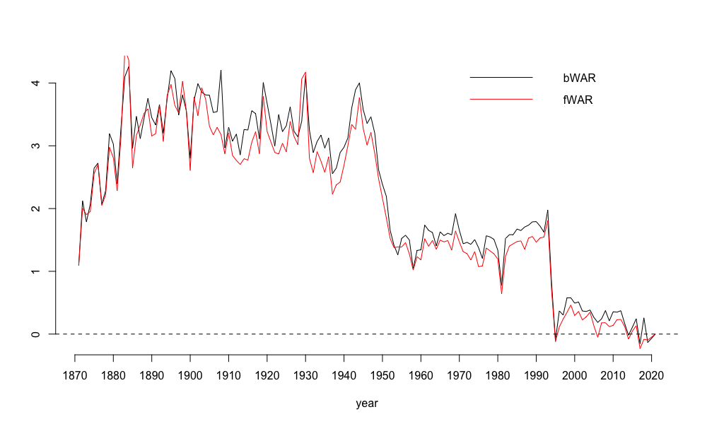

Returning to Kahrl’s point about Lou Gehrig and Honus Wagner, the Full House Model ranks several first basemen and shortstops above Gehrig and Wagner in career ebWAR:

| name | PA | AB | H | HR | BB | BA | OBP | ABpHR | ebWAR | efWAR | ebWARp100PA | efWARp100PA |
| --- | --- | --- | --- | --- | --- | --- | --- | --- | --- | --- | --- | --- |
| Albert Pujols | 12415 | 10628 | 3315 | 660 | 1474 | 0.312 | 0.398 | 16.10 | 111.03 | 97.29 | 0.89 | 0.78 |
| Jeff Bagwell | 9438 | 7669 | 2297 | 419 | 1343 | 0.300 | 0.408 | 18.30 | 84.30 | 84.95 | 0.89 | 0.90 |
| Miguel Cabrera | 10937 | 9375 | 2991 | 500 | 1368 | 0.319 | 0.406 | 18.75 | 83.16 | 80.77 | 0.76 | 0.74 |
| Frank Thomas | 9862 | 7869 | 2409 | 474 | 1589 | 0.306 | 0.423 | 16.60 | 79.53 | 76.38 | 0.81 | 0.77 |
| Lou Gehrig | 9481 | 7565 | 2235 | 432 | 1244 | 0.295 | 0.398 | 17.51 | 79.18 | 79.04 | 0.84 | 0.83 |

| name | PA | AB | H | HR | BB | BA | OBP | ABpHR | ebWAR | efWAR | ebWARp100PA | efWARp100PA |
| --- | --- | --- | --- | --- | --- | --- | --- | --- | --- | --- | --- | --- |
| Alex Rodriguez | 11784 | 9749 | 2914 | 597 | 1427 | 0.299 | 0.394 | 16.33 | 121.01 | 116.66 | 1.03 | 0.99 |
| Cal Ripken Jr. | 12668 | 11017 | 3073 | 411 | 1131 | 0.279 | 0.346 | 26.81 | 98.55 | 96.37 | 0.78 | 0.76 |
| Derek Jeter | 11457 | 9854 | 3111 | 272 | 1180 | 0.316 | 0.396 | 36.23 | 83.46 | 80.49 | 0.73 | 0.70 |
| Honus Wagner | 10644 | 8887 | 2533 | 239 | 294 | 0.285 | 0.316 | 37.18 | 80.81 | 80.76 | 0.76 | 0.76 |

Now there are cold emotionless era-adjusted statistics which back up Christina Kahrl. We can all now spend much less frustration mentally trying to unwind a previously intractable problem. Our method may not be perfect, but the big step of correcting for the talent imbalances which plague commonly used statistics in a sensible way has now been undertaken.

## ZiPS Projections

Let’s visit ZiPS Projections before we conclude this part of our series. Dan Szymborski closes a recent article with a discussion on [outlandish Juan Soto projections](https://blogs.fangraphs.com/elegy-for-2021-recapping-the-nl-east-team-by-team/) to which he says:

> I’ll admit it: I just wanted to see Soto break ZiPS. And I think he might have. Last spring, I spent some time talking with Jayson Stark about whether Soto was the next Ted Williams. The amazing thing is that neither of us thought the idea was absurd. MLB should simply redefine the strike zone as “whatever Juan Soto won’t swing at.” He might not always be the best overall player, but he’s the most gifted offensive player of this generation.

Here are the outlandish percentile Soto projections that Szymborski references:

[figure not shown]

Szymborski refers to Soto as breaking ZiPS. In other words, the projection system is unreliable for Soto. **We do not think that players break projection systems. Rather, projection systems are themselves broken if they produce nonsensical forecasts for players.** We do not know the inner mechanics of the ZiPS Projection System. If it borrows information from great players of the past to inform predictions about great players of the present, then its outputs may reflect era biases which have been discussed throughout this work. In a very unpopular public comment that was inspired by [Harry Crane’s 2018 article on election forecasting](https://researchers.one/articles/18.11.00005), Eck was willing to bet the under of the ZiPS 90th percentile of the Soto projections under the premise that it may have embedded era biases. Eck received a lot of public flack but ultimately got zero takers. We appreciate Dan Szymborski for even taking the time to acknowledge the circus that surrounded our point. We also enjoyed Dan’s amusing reveal that an unadulterated Ted Williams is indeed [Juan Soto’s closest comp](https://blogs.fangraphs.com/2022-zips-projections-washington-nationals/).

The tables below show what our method has to say about the accomplishments of Ted Williams and Juan Soto. From this, it makes sense that the era-adjusted version of Ted Williams would be a very close comp to the era-adjusted version of Juan Soto. These players are strikingly similar with a slight edge to Ted Williams so far, and a slight counter edge due to Soto entering the league at 19 while Williams entered at 20. Soto still has a while to go before his career rivals Williams’ career.

**First four seasons:**

| name | age | year | PA | AB | H | HR | BB | BA | OBP | ABpHR | HBP | SF | ebWAR | efWAR | ebWARp100PA | efWARp100PA |
| --- | --- | --- | --- | --- | --- | --- | --- | --- | --- | --- | --- | --- | --- | --- | --- | --- |
| Ted Williams | 20 | 1939 | 673 | 558 | 161 | 27 | 88 | 0.289 | 0.387 | 20.67 | 2 | 0 | 5.27 | 5.22 | 0.78 | 0.78 |
| Ted Williams | 21 | 1940 | 668 | 551 | 172 | 26 | 89 | 0.312 | 0.411 | 21.19 | 3 | 0 | 6.17 | 5.99 | 0.92 | 0.90 |
| Ted Williams | 22 | 1941 | 601 | 434 | 154 | 36 | 109 | 0.355 | 0.487 | 12.06 | 3 | 0 | 7.84 | 7.37 | 1.30 | 1.23 |
| Ted Williams | 23 | 1942 | 680 | 506 | 176 | 44 | 112 | 0.348 | 0.469 | 11.50 | 4 | 0 | 9.11 | 9.06 | 1.34 | 1.33 |
| Juan Soto | 19 | 2018 | 528 | 395 | 121 | 21 | 89 | 0.306 | 0.434 | 18.81 | 0 | 0 | 4.09 | 4.14 | 0.77 | 0.78 |
| Juan Soto | 20 | 2019 | 665 | 539 | 153 | 24 | 113 | 0.284 | 0.407 | 22.46 | 3 | 6 | 5.64 | 5.47 | 0.85 | 0.82 |
| Juan Soto | 21 | 2020 | 484 | 323 | 115 | 32 | 98 | 0.356 | 0.507 | 10.09 | 1 | 0 | 6.16 | 6.37 | 1.27 | 1.32 |
| Juan Soto | 22 | 2021 | 672 | 501 | 169 | 26 | 142 | 0.337 | 0.482 | 19.27 | 2 | 5 | 9.46 | 7.35 | 1.41 | 1.09 |

**First four seasons aggregated:**

| name | PA | AB | H | HR | BB | BA | OBP | ABpHR | ebWAR | efWAR | ebWARp100PA | efWARp100PA |
| --- | --- | --- | --- | --- | --- | --- | --- | --- | --- | --- | --- | --- |
| Ted Williams | 2622 | 2049 | 663 | 133 | 398 | 0.324 | 0.436 | 15.41 | 28.39 | 27.64 | 1.08 | 1.05 |
| Juan Soto | 2349 | 1758 | 558 | 103 | 442 | 0.317 | 0.454 | 17.07 | 25.35 | 23.33 | 1.08 | 0.99 |

**Aggregated stats through age 22:**

| name | PA | AB | H | HR | BB | BA | OBP | ABpHR | ebWAR | efWAR | ebWARp100PA | efWARp100PA |
| --- | --- | --- | --- | --- | --- | --- | --- | --- | --- | --- | --- | --- |
| Ted Williams | 1942 | 1543 | 487 | 89 | 286 | 0.316 | 0.425 | 17.34 | 19.28 | 18.58 | 0.99 | 0.96 |
| Juan Soto | 2349 | 1758 | 558 | 103 | 442 | 0.317 | 0.454 | 17.07 | 25.35 | 23.33 | 1.08 | 0.99 |

**Career stats:**

| name | PA | AB | H | HR | BB | BA | OBP | ABpHR | ebWAR | efWAR | ebWARp100PA | efWARp100PA |
| --- | --- | --- | --- | --- | --- | --- | --- | --- | --- | --- | --- | --- |
| Ted Williams | 10041 | 7528 | 2333 | 506 | 1662 | 0.310 | 0.436 | 14.88 | 96.09 | 100.23 | 0.96 | 1.00 |
| Juan Soto | 2349 | 1758 | 558 | 103 | 442 | 0.317 | 0.454 | 17.07 | 25.35 | 23.33 | 1.08 | 0.99 |

But Juan Soto compared to an unadulterated Ted Williams playing in a far inferior NL/AL? [Forget about it](https://www.youtube.com/watch?v=rGoXE_vo5XE).